# Model Fit

Mengran Li

2021/4/7

## 1. Introduction

General steps of GEV models:

1. Block by annual maximum
2. Moving windows and select breakpoints (if necessary)
3. Model fitting
4. Confidence Interval: Wald Confidence
5. Model Compare: AIC

For Region1,

take annual maximums of discharge from 1980-2019, totally 40 values.

```
##     DecYear        V1
##  1:    1980  348.2972
##  2:    1981  611.6439
##  3:    1982  509.7032
##  4:    1983  509.7032
##  5:    1984  535.1884
##  6:    1985  212.3763
##  7:    1986  410.5943
##  8:    1987 1019.4065
##  9:    1988  379.4457
## 10:    1989  622.9706
## 11:    1990  353.9606
## 12:    1991  421.9210
## 13:    1992  311.4853
## 14:    1993  733.4063
```

[output cut: 27 more lines]

## 2. Moving windows

Estimate stationary parameters in a window with a length of 10 years.

Then move to the next window, whose start year is 1 year later than the previous window’s start year.

Parameters are stationary in observing windows but no parameter is fixed during the whole 40 years. Results are in part 4.

Chosen Breakpoints (t):

```
##    mu sig sh
## 1  16  20 15
## 2  20  30 30
## 3  20  25 22
## 4  30  20 20
## 5  20  20 14
## 6  20  27 18
## 7  16  16 25
## 8  20  20 25
## 9  16  20 20
## 10 20  20 16
## 11 16  20 20
## 12 20  20 20
## 13 20  16 20
## 14 16  16 20
## 15 20  25 25
## 16 25  26 25
## 17 27  25 25
## 18 20  20 25
```

The year of 1980 is t=1, and the last year of 2019 is t=40.

## 3. Model fitting

$$\eta\in\{\mu,\sigma,\xi\}$$

$\mu$: location parameter

$\sigma$: scale parameter

$\xi$: shape parameter

### 3.1 Linear model

#### 3.1.1 Stationary model

$$\eta=\beta_0$$

#### 3.1.2 Single trend

$$\eta(t)=\beta_0+\beta_1{t}$$

#### 3.1.3 Double trends

Breakpoints are selected by moving window plots.

$$\eta(t)=\eta_0+\eta_1(1-D_1)(t-t_1)+\eta_2D_1(t-t_1)$$

where $D_1=\begin{cases}1, &t>{t_1} \\0, &other\ values\end{cases}$

All possible combinations of parameter formulations:

```
##            mu        sig         sh
## 1      double     double     double
## 2      double     double     single
## 3      double     double stationary
## 4      double     single     double
## 5      double     single     single
## 6      double     single stationary
## 7      double stationary     double
## 8      double stationary     single
## 9      double stationary stationary
## 10     single     double     double
## 11     single     double     single
## 12     single     double stationary
## 13     single     single     double
## 14     single     single     single
## 15     single     single stationary
## 16     single stationary     double
## 17     single stationary     single
## 18     single stationary stationary
## 19 stationary     double     double
## 20 stationary     double     single
## 21 stationary     double stationary
## 22 stationary     single     double
## 23 stationary     single     single
## 24 stationary     single stationary
## 25 stationary stationary     double
## 26 stationary stationary     single
## 27 stationary stationary stationary
```

#### 3.1.4 Result

The plots present 4 types of models.

- stationary model: all parameters are stationary.
- single trend model: best model of those contains stationary or single trend.
- double trend model: best model of those have at least one parameter with double trend.
- best model: best model of all linear models.

They are selected by AIC.

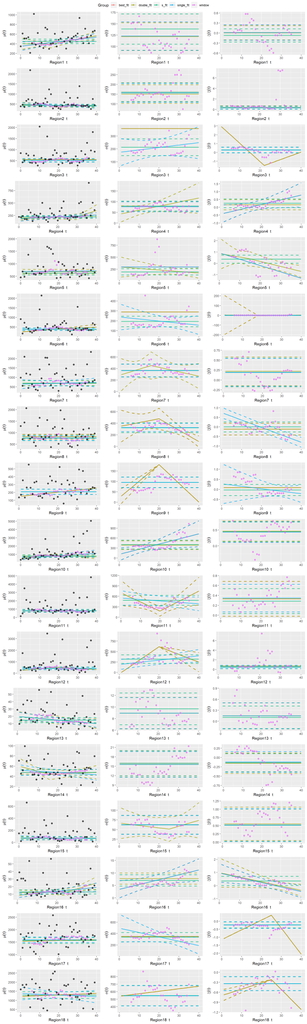

### 3.2 Abrupt model

$$\eta=\beta_0$$

$$\eta(t)=\beta_0+\beta_1{t}$$
or abrupt shift

Breakpoints are selected by moving window plots.

$$\eta(t)=\beta_0+\beta_1(1-D_1)(t-t_1)+\beta_1^*(1-D_1)+\beta_2D_1(t-t_1)+\beta_2^*D_1$$

where $D_1=\begin{cases}1, &t>{t_1} \\0, &other\ values\end{cases}$

But at least one of the parameters belongs to abrupt shifts. The models without abrupt shift have been estimated in the previous part.

Select best abrupt shift model according to AIC.

Plots can be seen in shiny.

### 3.3 Quadratic model

$$\eta=\beta_0$$

$$\eta(t)=\beta_0+\beta_1{t}$$

Quadratic trend

$$\eta(t)=\beta_0+\beta_1t+\beta_2t^2$$

At least one of the parameters belongs to quadratic trend.The models without quadratic trend have been estimated in the precious part.

Select best quadratic model according to AIC.

Plots can be seen in shiny.

### 3.4 Exponantial Model

$$\sigma(t)=e^{\beta_0}$$

$$\sigma(t)=e^{\beta_0+\beta_1t}$$

Breakpoints are selected by moving window plots.

$$\sigma(t)=e^{\beta_0+\beta_1(1-D_1)(t-t_1)+\beta_2D_1(t-t_1)}$$

where $D_1=\begin{cases}1, &t>{t_1} \\0, &other\ values\end{cases}$

$\mu$ and $\xi$ are stationary, single trend or double trend.

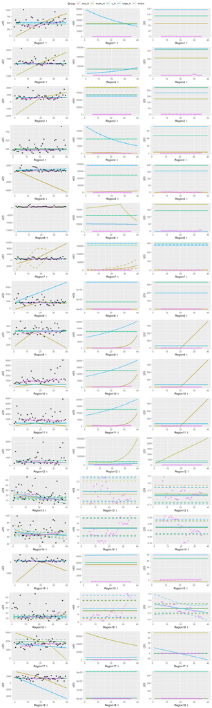

## 4 Model Compare

### 4.1 Best model

The plots display the best models among all GEV models selected by AIC.

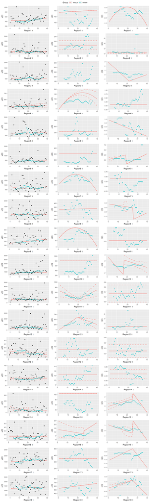

### 4.2 A Shiny to compare models

This [Model Fit Shiny](https://mengranli.shinyapps.io/model_fit/) *(link: https://mengranli.shinyapps.io/model_fit/)* is convenient to compare different models among different regions. Plots may be clear selecting 3-6 regions once. (Exponential model is not included in the app since its estimation is too large which will make other estimations compressed.)

Group:

- s_fit: stationary model in part 3.1 (1)
- single_fit: best single trend model in part 3.1 (2)
- double_fit: best double trend model in part 3.1 (3)
- linear_fit: best linear model in part 3.1
- abrupt_fit: best abrupt model in part 3.2
- quad_fit: best quadratic model in part 3.3
- best_fit: best model of all models estimated in part 3
- window: estimation of moving windows in part 2

Black dots in the first column are original data of annual maxima.

Dashed lines are 95% confidence intervals.

## 5 Issues

1. Given the rare observations (40) but high dimensions (some models reach around 15), the matrix sometimes is singular so that MLE estimation is not available.
2. Missing or incomplete confidence intervals are also caused by the same reason. Bootstrap can not be carried out either.
3. Abrupt model should have two stages that are not connected, but when I draw the plot in ggplot, geom_line will connect two points (t, t+1) automatically. In which case, the graph looks like a triple trend, but I haven’t the estimated triple trend model (I’m worried about the too high dimensions if take the form). It may take some time to modify this. If it is necessary, I will fix this problem.
4. Exponential models look strange (I have checked code estimating these models many times, and at least up to now, there is no mistake found).
5. The estimation lines don’t follow moving windows every time. I guess that is because, extreme values will make moving windows estimations greater, which is a stationary model, and once the extreme values are out of the observing window, the estimations of moving windows will drop down suddenly.
6. As we talked about last time, I don’t trust the chosen breakpoints very much.
7. The estimations of different models may overlap in the plots (alpha didn’t improve the situation). So if lacking any model, it may be caused by this reason. Hide other models, we can see interested one clearly. But pay attention that there are some models not estimated because of singular matrix.
8. If the estimated best models of two regions are similar (parameter plot), can we regard them as similar? Then use the bivariate model?

## 6 GPD models

There still are several questions:

1. Threshold Choice Plots (tcplot) keep stationary in eg. (400, 1000), which is a really wide interval. And when u=400, there are 481 observations, when u=600 there are 92 observations, while when u=1000, there only 10 left. Given that we have $n\times10^{6}$ observations totally for each region, is it reasonable to select a lower threshold, in this case u=400? I know the impact of data on bias and variance but still have no feeling (intuition? experience?) about this situation.
2. AIC changes greatly with the number of observations. So do likelihood. It may not a good idea to compare GPD models by AIC? Or just compare models whose parameters are stationary or single trend after choosing threshold. Is there any way to compare GEV with GPD? Or they are different type models, so we should choose them by advantage and disadvantage instead of any criterion like AIC, Chisq test?
3. Should GPD models be estimated in the same forms as GEVs, stationary, single, double, double, and others? (May not quite difficult to realize)